# LA12

Braden Griebel, Andrew Duffy, Ahyo Falick, Luke Fanning

11/11/2019

```r
perm_mean <- function(perms = 1000, all_values, n_A)
{
  ## Variables ##
  # perms: The number of permutations
  # all_values (num): all data values
  # n_A (int): Size of group A
  ###############

  # Step 1:
  # Create vector of zeroes of length "perms" to store
  # permuted mean differnces
  permuted_mean_differences<-rep(0,perms)

  # Loop throught number of permutations
  for (i in c(1:perms))
  {
    # Step 2:
    # Randomly separate vector "values" into disjoint
    # groups of size "nA" and "nB" respectively
    temp<-sample(all_values)
    group_A<-temp[1:n_A]
    group_B<-temp[(n_A+1):length(temp)]

    # Step 3:
    # Compute the sample means for the two groups from
    # step 2
    mean_A<-mean(group_A,na.rm=T)
    mean_B<-mean(group_B,na.rm=T)


    # Step 4:
    # Compute the difference in sample means, store the
    # value in the vector from step 1
    permuted_mean_differences[i]<-mean_A-mean_B

  }

  # Step 5:
  # Return the permuted mean differences vector
  return(permuted_mean_differences)

}
```

```r
perm_cor <- function(perms = 1000, x, y)
{
  ## Variables ##
  # perms: The number of permutations
  # x: Vector of Variable 1 - for computing correlation
  # y: Vector of Variable 2 - for computing correlation
  ###############

  # Step 1:
  # Create vector of zeroes of length "perms" to store
  # permuted mean differnces
  correlations<-rep(0,perms)


  # Loop throught number of permutations
  for (i in c(1:perms))
  {
    # Step 2:
    # Randomly mix up the values in the vector "y"
    temp<-sample(y)

    # Step 3:
    # Compute the correlation between x and the randomly mixed
    # up y-vector. Store this value in the vector from step 1.
    correlations[i]<-cor(x,temp,use="pairwise.complete.obs")

  }

  # Step 4:
  # Return new updated vector, created in step 1
  return(correlations)

}
```

```r
#gap_data<-read_delim(file="gapminder.csv",delim=",",col_types = cols(
#  country=col_factor(),
#  continent=col_factor(),
#  year=col_integer(),
#  lifeExp=col_double(),
#  pop=col_integer(),
#  gdpPercap=col_double()
#
#))
gap_data<-gapminder_unfiltered
```

## Data Description:

The gapminder dataset has life expectancy, population, and GDP per capita by year and country. The continent of the country is also recorded. The years range from 1952 to 2007.

## Question 1:

Is there a difference in the correlation between GDP and Life Expectancy between Europe and Asia?  
$H_0$:Cor(GDP per capita, Life expectancy) in Europe $-$ Cor(GDP per capita, Life expectancy) in Asia $=$ 0  
$H_1$:Cor(GDP per capita, Life expectancy) in Europe $-$ Cor(GDP per capita, Life expectancy) in Asia $\neq$ 0  
We will reject the null, and accept the alternative hypothesis and reject the null if and only if percentile of the difference in means is under $2.5\%$ or above $97.5\%$

### Why this Question is Interesting:

There is a correlation between life expectancy and per capita GDP (can be shown with a permutation test), but is this correlation as strong in different regions? This is interesting because it can allow us to see what aspects can affect this correlation. This is important because it can allow for an understanding of how life expectancy is affected by a variety of different variables. This in turn would allow for programs to reduce the disparity in life expectancy between the more and less wealthy countries (by increasing the life expenctancy of the less wealthy countries and not decreasing the life expectancy of the wealthier countries, although that would be easier given the amount of nuclear weapons on the planet).

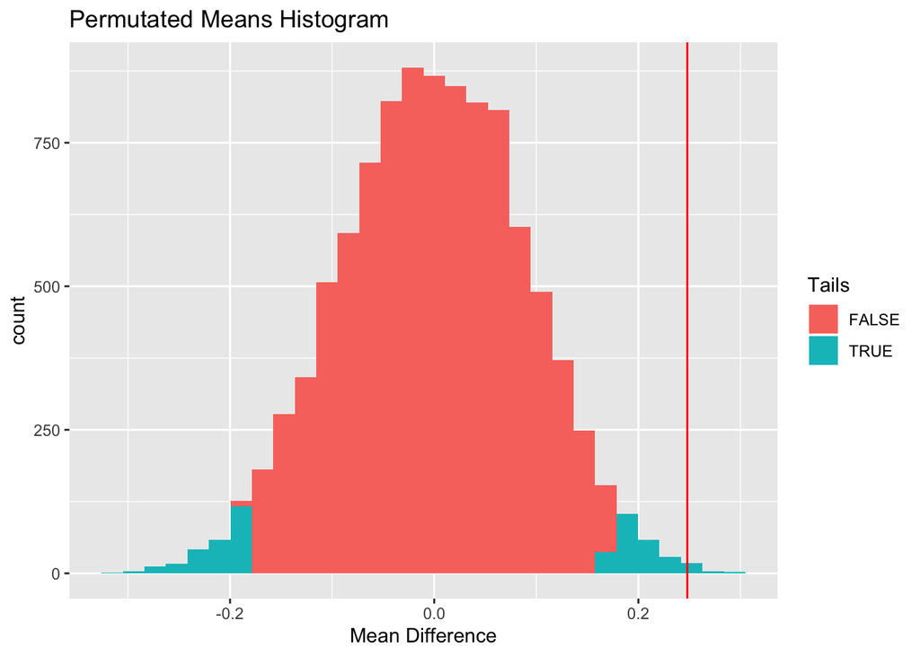

```r
set.seed(25)
gap_data2<-gap_data%>%group_by(continent,country)%>%summarize(correlation=cor(gdpPercap,lifeExp))%>%filter(continent=="Asia"|continent=="Europe")

gap_dataAsia<-gap_data2%>%filter(continent=="Asia")
gap_dataEurope<-gap_data2%>%filter(continent=="Europe")
cor_diff<-mean(gap_dataEurope$correlation)-mean(gap_dataAsia$correlation)

permutation_diff<-perm_mean(perms=10000,all_values=gap_data2$correlation,n_A=length(gap_dataEurope$correlation))
permutaion_diff<-tibble("correlation"=permutation_diff)
ggplot(data=permutaion_diff)+geom_histogram(aes(x=correlation,fill=(correlation<quantile(correlation,probs = c(.025))[[1]]|correlation>quantile(correlation,probs = c(.975))[[1]])))+
  geom_vline(xintercept=cor_diff,color="red")+
  labs(title="Permutated Means Histogram",fill="Tails",x="Mean Difference")
```

```r
percentile=sum(permutaion_diff<cor_diff)/nrow(permutaion_diff)*100
stats<-tribble(
  ~Statistic,              ~Value,
  #--|--|----
  "Mean", mean(permutaion_diff$correlation),
  "Median", median(permutaion_diff$correlation),
  "Max", max(permutaion_diff$correlation),
  "Min", min(permutaion_diff$correlation),
  "2.5 Percentile", quantile(permutaion_diff$correlation,probs=c(.025))[[1]],
  "97.5 Percentile", quantile(permutaion_diff$correlation,probs=c(.975))[[1]],
  "Calculated Mean Difference",cor_diff,
  "Percentile",percentile
)
stats
```

```
## # A tibble: 8 x 2
##   Statistic                      Value
##   <chr>                          <dbl>
## 1 Mean                       -0.00112
## 2 Median                     -0.000202
## 3 Max                         0.294
## 4 Min                        -0.316
## 5 2.5 Percentile             -0.179
## 6 97.5 Percentile             0.173
## 7 Calculated Mean Difference  0.248
## 8 Percentile                 99.8
```

## Question 2:

Is there a correlation between population and GDP per capita for the African continent?  
$H_0:\rho=0$  
$H_1:\rho\neq0$  
We will reject the null, and accept the alternative hypothesis and reject the null if and only if percentile of the difference in means is under $2.5\%$ or above $97.5\%$

### Why is this question Important:

This question can allow us to examine the relationship between people and their economy. If population is correlated positively with GDP per capita, it would show that each additional person adds more value to the economy than the average from all the other people. That is, they had to add more to the GDP than dividing by an additional person in the per capita calculation could account for. If population was negatively correlated with GDP per capita, than each additional person adds less to the economy than the previous average before they were included. If the GDP per capita isn’t correlated with population, than each additional person adds roughly the same amount to an economy as anyone before them. This can tell us a lot about the economies. For example, if the economies were saturated, and any new people would be unable to produce additional GDP, then we would expect a negative correlation. If the economy was undersaturated, such that additional people allow for a lot more to be produced (by increasing the efficiencies that the economy is capable of,since you need a certain number of people to organize to increase efficiency) we would expect a positive correlation. A zero correlation would show that the economies are in the middle of this range. This data would help us in predicting what will happen to the economies as the population grows in future years. Understanding the likely economic possibilities of these countries could allow the governments to make plans that help all of their citizens live healthier and happier lives.

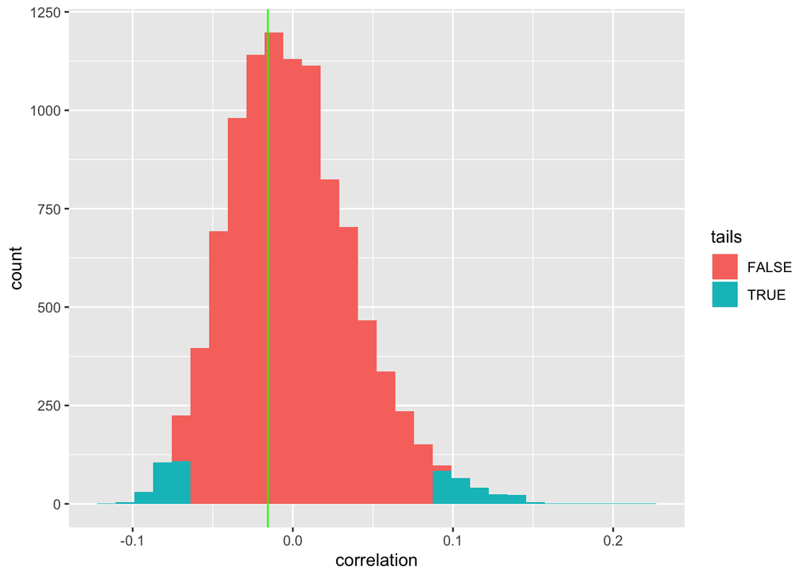

```r
i="Africa"
gap_data3<-gap_data%>%filter(continent==i)
thing1<-gap_data3$pop
thing2<-gap_data3$gdpPercap
correlations<-perm_cor(perms=10000,thing1,thing2)
correlations<-tibble("correlation"=correlations)
calculated_cor<-cor(thing1,thing2)
ggplot(data=correlations,aes(x=correlation,fill=(correlation<quantile(correlation,probs = c(.025),na.rm=T)[[1]]|correlation>quantile(correlation,probs = c(.975),na.rm=T)[[1]])))+geom_histogram()+
  geom_vline(xintercept=calculated_cor,color="green")+
  labs(fill="tails")
```

```r
percentile<-length(correlations$correlation[correlations$correlation<calculated_cor])/nrow(correlations)
stats<-tribble(
  ~Statistic,              ~Value,
  #--|--|----
  "Mean", mean(correlations$correlation,na.rm=T),
  "Median", median(correlations$correlation,na.rm=T),
  "Max", max(correlations$correlation,na.rm=T),
  "Min", min(correlations$correlation,na.rm=T),
  "2.5 Percentile", quantile(correlations$correlation,probs=c(.025))[[1]],
  "97.5 Percentile", quantile(correlations$correlation,probs=c(.975))[[1]],
  "Calculated Correlation",calculated_cor,
  "Percentile",percentile
)
stats
```

```
## # A tibble: 8 x 2
##   Statistic                  Value
##   <chr>                      <dbl>
## 1 Mean                   -0.000168
## 2 Median                 -0.00343
## 3 Max                     0.219
## 4 Min                    -0.119
## 5 2.5 Percentile         -0.0694
## 6 97.5 Percentile         0.0885
## 7 Calculated Correlation -0.0156
## 8 Percentile              0.376
```

### Conclusion:

Based on the above, it can be seen that there is not a significant correlation between GDP per capita and population. Since the correlation between GDP per capita and population is in the 37th percentile, it is not in either of the tails of the data. This can be seen on the graph, where the line representing the calculated value for this correlation is roughly in the center. This value is quite close to the mean of zero, and shows that the null hypothesis should be upheld, that is there is no significant correlation between GDP per capita and population.

## Individual Contributions:

I, Braden Griebel, implemented the perm_mean function and used it to run a permutation test on the correlation between Life expectancy and GDP per capita differed between Europe and Asia. I added colour to the graph to show where its tails were, in order to demonstrate whether the difference in mean correlation between Europe and Asia was significant. I also added a vertical line to show where the calculated difference in means lay.

I, Luke Fanning, proofread Braden’s work. I also implemented my own versions of the functions in a separate file and ran my own permutation and correlation tests. My permutation test tested the difference in mean GDP per capita between North and Central African countries and found the difference to be statistically significant, whereas my correlation test tested for a correlation between GDP per capita and life expectancy and found a correlation. I graphed each of these tests on a histogram and added the relevant correlation and/or mean on the graph through the use of a vertical line.

I, Ahyo Falick, assisted in this lab by creating my own different version of the lab. As a group we decided on the use of Braden’s functions in the end because it is more efficiently answers the questions asked. My correlation test was able to find a correlation between between the data given and I used a geom_smooth function to plot the correlations with the mean being a vertical line.

I, Andrew Duffy, implemented my own functions regarding the 2 permutation tests, testing for the correlation between Europe and North America regarding life expectancy vs. GDP per capita, in which there was a fairly significant correlation when running the permutation tests. I accepted the null hypothesis that Europe and North America have similar correlations between life expectancy and GDP. I also tested the correlations between GDP per capita and fertility rate in South east Asia, for which there were no correlations. I graphed both of these with a bar plot, with a solid line denoting the mean.